# IS 670 Lab 10: Association Rule Mining

Market basket analysis is used behind the scenes for the recommendation systems used in many brick-and-mortar and online retailers. The learned association rules indicate the combinations of items that are often purchased together. Knowledge of these patterns provides insight into new ways a grocery chain might optimize the inventory, advertise promotions,or organize the physical layout of the store. For instance, if shoppers frequently purchase coffee or orange juice with a breakfast pastry, it may be possible to increase profit by relocating pastries closer to coffee and juice.  
In this lab, we will perform a market basket analysis of transactional data from a grocery store.Our market basket analysis will utilize the purchase data collected from one month of operation at a real-world grocery store. The data contains 9,835 transactions.

### 1. Upload and clean data

```python
# Mount Google Drive (upload `groceries.csv` to My Drive, e.g. folder IS670_data)
from google.colab import drive

drive.mount("/content/drive")
```

```python
# Import libraries
!pip install -q apyori
import pandas as pd
import numpy as np
from csv import reader
import seaborn as sns
from apyori import apriori

# Dataset on Drive (upload groceries.csv here or change the path)
GROCERIES_CSV = "/content/drive/MyDrive/IS 670/groceries.csv"
```

```python
# Read data line by line from Drive (GROCERIES_CSV is set in the imports cell)
groceries = []
with open(GROCERIES_CSV, "r", encoding="utf-8") as read_obj:
    csv_reader = reader(read_obj)
    for row in csv_reader:
        groceries.append(row)
```

```python
# Inspect the first 5 transactions
groceries[:5]
```

```
[['citrus fruit', 'semi-finished bread', 'margarine', 'ready soups'],
 ['tropical fruit', 'yogurt', 'coffee'],
 ['whole milk'],
 ['pip fruit', 'yogurt', 'cream cheese ', 'meat spreads'],
 ['other vegetables',
  'whole milk',
  'condensed milk',
  'long life bakery product']]
```

## 2. Data exploration

```python
# Show the number of transactions
len(groceries)
```

```
9835
```

```python
# Show the number of unique items
flat_list = np.concatenate(groceries).flat
unique_item, item_count = np.unique(flat_list, return_counts=True)
print("number of unique items:", len(unique_item))
```

```
number of unique items: 169
```

**Q1. What is the purpose of flat_list?**

`flat_list` turns every purchased item from every basket into one long sequence of product names. That shape lets you measure how often each SKU appears using `np.unique` or pandas `value_counts`. If you keep only the nested transaction lists, you cannot count item frequencies across the whole store in one step.

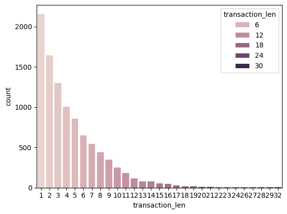

```python
# Plot the distribution of transaction length
transaction_len = []
for transaction in groceries:
  transaction_len.append(len(transaction))
sns.countplot(x = 'transaction_len', hue = 'transaction_len',  data = pd.DataFrame({'transaction_len':transaction_len}))
```

```python
# Examine the absolute frquency of items in descending order
item_frequency = pd.DataFrame({'items':flat_list})
item_frequency.value_counts()
```

| items | count |
| --- | --- |
| whole milk | 2513 |
| other vegetables | 1903 |
| rolls/buns | 1809 |
| soda | 1715 |
| yogurt | 1372 |
| bottled water | 1087 |
| root vegetables | 1072 |
| tropical fruit | 1032 |
| shopping bags | 969 |
| sausage | 924 |
| pastry | 875 |
| citrus fruit | 814 |
| bottled beer | 792 |
| newspapers | 785 |
| canned beer | 764 |
| pip fruit | 744 |
| fruit/vegetable juice | 711 |
| whipped/sour cream | 705 |
| brown bread | 638 |
| domestic eggs | 624 |
| frankfurter | 580 |
| margarine | 576 |
| coffee | 571 |
| pork | 567 |
| butter | 545 |
| curd | 524 |
| beef | 516 |
| napkins | 515 |
| chocolate | 488 |
| frozen vegetables | 473 |

[output cut: 139 more lines]

**dtype:** int64

```python
# Examine the relative frquency of items in descending order
item_frequency.value_counts()/len(groceries)
```

| items | count |
| --- | --- |
| whole milk | 0.255516 |
| other vegetables | 0.193493 |
| rolls/buns | 0.183935 |
| soda | 0.174377 |
| yogurt | 0.139502 |
| bottled water | 0.110524 |
| root vegetables | 0.108998 |
| tropical fruit | 0.104931 |
| shopping bags | 0.098526 |
| sausage | 0.093950 |
| pastry | 0.088968 |
| citrus fruit | 0.082766 |
| bottled beer | 0.080529 |
| newspapers | 0.079817 |
| canned beer | 0.077682 |
| pip fruit | 0.075648 |
| fruit/vegetable juice | 0.072293 |
| whipped/sour cream | 0.071683 |
| brown bread | 0.064870 |
| domestic eggs | 0.063447 |
| frankfurter | 0.058973 |
| margarine | 0.058566 |
| coffee | 0.058058 |
| pork | 0.057651 |
| butter | 0.055414 |
| curd | 0.053279 |
| beef | 0.052466 |
| napkins | 0.052364 |
| chocolate | 0.049619 |
| frozen vegetables | 0.048094 |

[output cut: 139 more lines]

**dtype:** float64

**Q2. What are the support values for top 3 most frequent items?**

Treat each item’s basket share as its singleton support: whole milk is about **0.256** (25.6% of 9,835 baskets). **Other vegetables** is about **0.194** (19.4%). **Rolls/buns** is about **0.184** (18.4%). Each value is the item count divided by the number of transactions.

## 3. Use the apriori algorithm to generate association rules

```python
# Use the apriori command to generate rules with minimal support = 0.01, minimal confidence = 0.3, and max length = 2.
groceries_rules = apriori(groceries, min_support = 0.01, min_confidence = 0.3, max_length=2)
groceries_rules = list(groceries_rules)
```

```python
# Collect all rule info in a list and display them
rows = [
    {
        'LHS': ','.join(rule_.items_base),
        'RHS': ','.join(rule_.items_add),
        'support': rule.support,
        'confidence': rule_.confidence,
        'lift': rule_.lift
    }
    for rule in groceries_rules
    for rule_ in rule.ordered_statistics
]

# Convert once to DataFrame
all_rules = pd.DataFrame(rows, columns=['LHS', 'RHS', 'support', 'confidence', 'lift'])

# Display settings
pd.options.display.max_rows = 999
all_rules
```

|  | LHS | RHS | support | confidence | lift |
| --- | --- | --- | --- | --- | --- |
| 0 | beef | other vegetables | 0.019725 | 0.375969 | 1.943066 |
| 1 | beef | root vegetables | 0.017387 | 0.331395 | 3.040367 |
| 2 | beef | whole milk | 0.021251 | 0.405039 | 1.585180 |
| 3 | berries | other vegetables | 0.010269 | 0.308869 | 1.596280 |
| 4 | berries | whole milk | 0.011795 | 0.354740 | 1.388328 |
| 5 | berries | yogurt | 0.010574 | 0.318043 | 2.279848 |
| 6 | bottled water | whole milk | 0.034367 | 0.310948 | 1.216940 |
| 7 | brown bread | whole milk | 0.025216 | 0.388715 | 1.521293 |
| 8 | butter | other vegetables | 0.020031 | 0.361468 | 1.868122 |
| 9 | butter | whole milk | 0.027555 | 0.497248 | 1.946053 |
| 10 | butter milk | other vegetables | 0.010371 | 0.370909 | 1.916916 |
| 11 | butter milk | whole milk | 0.011591 | 0.414545 | 1.622385 |
| 12 | chicken | other vegetables | 0.017895 | 0.417062 | 2.155439 |
| 13 | chicken | whole milk | 0.017590 | 0.409953 | 1.604411 |
| 14 | chocolate | whole milk | 0.016675 | 0.336066 | 1.315243 |
| 15 | citrus fruit | other vegetables | 0.028876 | 0.348894 | 1.803140 |
| 16 | citrus fruit | whole milk | 0.030503 | 0.368550 | 1.442377 |
| 17 | coffee | whole milk | 0.018709 | 0.322242 | 1.261141 |
| 18 | cream cheese | other vegetables | 0.013726 | 0.346154 | 1.788977 |
| 19 | cream cheese | whole milk | 0.016472 | 0.415385 | 1.625670 |
| 20 | cream cheese | yogurt | 0.012405 | 0.312821 | 2.242412 |
| 21 | curd | other vegetables | 0.017184 | 0.322519 | 1.666829 |
| 22 | curd | whole milk | 0.026131 | 0.490458 | 1.919481 |
| 23 | curd | yogurt | 0.017285 | 0.324427 | 2.325615 |
| 24 | dessert | other vegetables | 0.011591 | 0.312329 | 1.614164 |
| 25 | dessert | whole milk | 0.013726 | 0.369863 | 1.447514 |
| 26 | domestic eggs | other vegetables | 0.022267 | 0.350962 | 1.813824 |
| 27 | domestic eggs | whole milk | 0.029995 | 0.472756 | 1.850203 |
| 28 | frankfurter | rolls/buns | 0.019217 | 0.325862 | 1.771616 |
| 29 | frankfurter | whole milk | 0.020539 | 0.348276 | 1.363029 |
| 30 | frozen vegetables | other vegetables | 0.017794 | 0.369979 | 1.912108 |
| 31 | frozen vegetables | whole milk | 0.020437 | 0.424947 | 1.663094 |
| 32 | fruit/vegetable juice | whole milk | 0.026640 | 0.368495 | 1.442160 |
| 33 | ham | whole milk | 0.011490 | 0.441406 | 1.727509 |
| 34 | hamburger meat | other vegetables | 0.013828 | 0.415902 | 2.149447 |
| 35 | hamburger meat | whole milk | 0.014743 | 0.443425 | 1.735410 |
| 36 | hard cheese | whole milk | 0.010066 | 0.410788 | 1.607682 |
| 37 | hygiene articles | whole milk | 0.012811 | 0.388889 | 1.521975 |
| 38 | long life bakery product | whole milk | 0.013523 | 0.361413 | 1.414444 |
| 39 | margarine | other vegetables | 0.019725 | 0.336806 | 1.740663 |
| 40 | margarine | whole milk | 0.024199 | 0.413194 | 1.617098 |
| 41 | napkins | whole milk | 0.019725 | 0.376699 | 1.474268 |
| 42 | newspapers | whole milk | 0.027351 | 0.342675 | 1.341110 |
| 43 | oil | whole milk | 0.011286 | 0.402174 | 1.573968 |
| 44 | onions | other vegetables | 0.014235 | 0.459016 | 2.372268 |
| 45 | onions | whole milk | 0.012100 | 0.390164 | 1.526965 |
| 46 | pip fruit | other vegetables | 0.026131 | 0.345430 | 1.785237 |
| 47 | pork | other vegetables | 0.021657 | 0.375661 | 1.941476 |
| 48 | root vegetables | other vegetables | 0.047382 | 0.434701 | 2.246605 |
| 49 | sugar | other vegetables | 0.010778 | 0.318318 | 1.645119 |
| 50 | tropical fruit | other vegetables | 0.035892 | 0.342054 | 1.767790 |
| 51 | whipped/sour cream | other vegetables | 0.028876 | 0.402837 | 2.081924 |
| 52 | white bread | other vegetables | 0.013726 | 0.326087 | 1.685268 |
| 53 | other vegetables | whole milk | 0.074835 | 0.386758 | 1.513634 |
| 54 | yogurt | other vegetables | 0.043416 | 0.311224 | 1.608457 |
| 55 | pastry | whole milk | 0.033249 | 0.373714 | 1.462587 |
| 56 | pip fruit | whole milk | 0.030097 | 0.397849 | 1.557043 |
| 57 | pork | whole milk | 0.022166 | 0.384480 | 1.504719 |
| 58 | sausage | rolls/buns | 0.030605 | 0.325758 | 1.771048 |
| 59 | rolls/buns | whole milk | 0.056634 | 0.307905 | 1.205032 |
| 60 | root vegetables | whole milk | 0.048907 | 0.448694 | 1.756031 |
| 61 | sausage | whole milk | 0.029893 | 0.318182 | 1.245252 |
| 62 | sliced cheese | whole milk | 0.010778 | 0.439834 | 1.721356 |
| 63 | sugar | whole milk | 0.015048 | 0.444444 | 1.739400 |
| 64 | tropical fruit | whole milk | 0.042298 | 0.403101 | 1.577595 |
| 65 | waffles | whole milk | 0.012710 | 0.330688 | 1.294196 |
| 66 | whipped/sour cream | whole milk | 0.032232 | 0.449645 | 1.759754 |
| 67 | white bread | whole milk | 0.017082 | 0.405797 | 1.588147 |
| 68 | yogurt | whole milk | 0.056024 | 0.401603 | 1.571735 |

**Q3. How many rules are generated?**

With minimum support 0.01, minimum confidence 0.30, and maximum length 2, Apyori produces **69** rules when every `ordered_statistics` entry is counted as its own row in the rules table. That total is the height of the `all_rules` dataframe built in the lab. Changing thresholds would change the rule count.

```python
# Display all rules sorted by confidence levels
all_rules.sort_values(by ='lift', ascending = False)
```

|  | LHS | RHS | support | confidence | lift |
| --- | --- | --- | --- | --- | --- |
| 1 | beef | root vegetables | 0.017387 | 0.331395 | 3.040367 |
| 44 | onions | other vegetables | 0.014235 | 0.459016 | 2.372268 |
| 23 | curd | yogurt | 0.017285 | 0.324427 | 2.325615 |
| 5 | berries | yogurt | 0.010574 | 0.318043 | 2.279848 |
| 48 | root vegetables | other vegetables | 0.047382 | 0.434701 | 2.246605 |
| 20 | cream cheese | yogurt | 0.012405 | 0.312821 | 2.242412 |
| 12 | chicken | other vegetables | 0.017895 | 0.417062 | 2.155439 |
| 34 | hamburger meat | other vegetables | 0.013828 | 0.415902 | 2.149447 |
| 51 | whipped/sour cream | other vegetables | 0.028876 | 0.402837 | 2.081924 |
| 9 | butter | whole milk | 0.027555 | 0.497248 | 1.946053 |
| 0 | beef | other vegetables | 0.019725 | 0.375969 | 1.943066 |
| 47 | pork | other vegetables | 0.021657 | 0.375661 | 1.941476 |
| 22 | curd | whole milk | 0.026131 | 0.490458 | 1.919481 |
| 10 | butter milk | other vegetables | 0.010371 | 0.370909 | 1.916916 |
| 30 | frozen vegetables | other vegetables | 0.017794 | 0.369979 | 1.912108 |
| 8 | butter | other vegetables | 0.020031 | 0.361468 | 1.868122 |
| 27 | domestic eggs | whole milk | 0.029995 | 0.472756 | 1.850203 |
| 26 | domestic eggs | other vegetables | 0.022267 | 0.350962 | 1.813824 |
| 15 | citrus fruit | other vegetables | 0.028876 | 0.348894 | 1.803140 |
| 18 | cream cheese | other vegetables | 0.013726 | 0.346154 | 1.788977 |
| 46 | pip fruit | other vegetables | 0.026131 | 0.345430 | 1.785237 |
| 28 | frankfurter | rolls/buns | 0.019217 | 0.325862 | 1.771616 |
| 58 | sausage | rolls/buns | 0.030605 | 0.325758 | 1.771048 |
| 50 | tropical fruit | other vegetables | 0.035892 | 0.342054 | 1.767790 |
| 66 | whipped/sour cream | whole milk | 0.032232 | 0.449645 | 1.759754 |
| 60 | root vegetables | whole milk | 0.048907 | 0.448694 | 1.756031 |
| 39 | margarine | other vegetables | 0.019725 | 0.336806 | 1.740663 |
| 63 | sugar | whole milk | 0.015048 | 0.444444 | 1.739400 |
| 35 | hamburger meat | whole milk | 0.014743 | 0.443425 | 1.735410 |
| 33 | ham | whole milk | 0.011490 | 0.441406 | 1.727509 |
| 62 | sliced cheese | whole milk | 0.010778 | 0.439834 | 1.721356 |
| 52 | white bread | other vegetables | 0.013726 | 0.326087 | 1.685268 |
| 21 | curd | other vegetables | 0.017184 | 0.322519 | 1.666829 |
| 31 | frozen vegetables | whole milk | 0.020437 | 0.424947 | 1.663094 |
| 49 | sugar | other vegetables | 0.010778 | 0.318318 | 1.645119 |
| 19 | cream cheese | whole milk | 0.016472 | 0.415385 | 1.625670 |
| 11 | butter milk | whole milk | 0.011591 | 0.414545 | 1.622385 |
| 40 | margarine | whole milk | 0.024199 | 0.413194 | 1.617098 |
| 24 | dessert | other vegetables | 0.011591 | 0.312329 | 1.614164 |
| 54 | yogurt | other vegetables | 0.043416 | 0.311224 | 1.608457 |
| 36 | hard cheese | whole milk | 0.010066 | 0.410788 | 1.607682 |
| 13 | chicken | whole milk | 0.017590 | 0.409953 | 1.604411 |
| 3 | berries | other vegetables | 0.010269 | 0.308869 | 1.596280 |
| 67 | white bread | whole milk | 0.017082 | 0.405797 | 1.588147 |
| 2 | beef | whole milk | 0.021251 | 0.405039 | 1.585180 |
| 64 | tropical fruit | whole milk | 0.042298 | 0.403101 | 1.577595 |
| 43 | oil | whole milk | 0.011286 | 0.402174 | 1.573968 |
| 68 | yogurt | whole milk | 0.056024 | 0.401603 | 1.571735 |
| 56 | pip fruit | whole milk | 0.030097 | 0.397849 | 1.557043 |
| 45 | onions | whole milk | 0.012100 | 0.390164 | 1.526965 |
| 37 | hygiene articles | whole milk | 0.012811 | 0.388889 | 1.521975 |
| 7 | brown bread | whole milk | 0.025216 | 0.388715 | 1.521293 |
| 53 | other vegetables | whole milk | 0.074835 | 0.386758 | 1.513634 |
| 57 | pork | whole milk | 0.022166 | 0.384480 | 1.504719 |
| 41 | napkins | whole milk | 0.019725 | 0.376699 | 1.474268 |
| 55 | pastry | whole milk | 0.033249 | 0.373714 | 1.462587 |
| 25 | dessert | whole milk | 0.013726 | 0.369863 | 1.447514 |
| 16 | citrus fruit | whole milk | 0.030503 | 0.368550 | 1.442377 |
| 32 | fruit/vegetable juice | whole milk | 0.026640 | 0.368495 | 1.442160 |
| 38 | long life bakery product | whole milk | 0.013523 | 0.361413 | 1.414444 |
| 4 | berries | whole milk | 0.011795 | 0.354740 | 1.388328 |
| 29 | frankfurter | whole milk | 0.020539 | 0.348276 | 1.363029 |
| 42 | newspapers | whole milk | 0.027351 | 0.342675 | 1.341110 |
| 14 | chocolate | whole milk | 0.016675 | 0.336066 | 1.315243 |
| 65 | waffles | whole milk | 0.012710 | 0.330688 | 1.294196 |
| 17 | coffee | whole milk | 0.018709 | 0.322242 | 1.261141 |
| 61 | sausage | whole milk | 0.029893 | 0.318182 | 1.245252 |
| 6 | bottled water | whole milk | 0.034367 | 0.310948 | 1.216940 |
| 59 | rolls/buns | whole milk | 0.056634 | 0.307905 | 1.205032 |

```python
# Display the top 5 rules sorted by confidence levels
all_rules.sort_values(by ='confidence', ascending = False)[:5]
```

|  | LHS | RHS | support | confidence | lift |
| --- | --- | --- | --- | --- | --- |
| 9 | butter | whole milk | 0.027555 | 0.497248 | 1.946053 |
| 22 | curd | whole milk | 0.026131 | 0.490458 | 1.919481 |
| 27 | domestic eggs | whole milk | 0.029995 | 0.472756 | 1.850203 |
| 44 | onions | other vegetables | 0.014235 | 0.459016 | 2.372268 |
| 66 | whipped/sour cream | whole milk | 0.032232 | 0.449645 | 1.759754 |

**Q4. What is the probability of buying whole milk when butter is purchased?**

That quantity is the conditional probability P(whole milk | butter), which equals the **confidence** of the rule {butter} → {whole milk}. In this dataset the value is about **0.497**, so roughly half of baskets with butter also contain whole milk. You should read that number directly from the row where butter is on the left and whole milk is on the right.

**Q5. What is the probability of buying butter and whole milk together?**

That joint probability is the **support** of the itemset {butter, whole milk}, which matches the support reported for the association rule linking them. Here it is about **0.0276**, meaning about 2.8% of all transactions include both products. Support always measures how often the full combined itemset appears in a basket.

**Q6. Interpret the first rule based on the values of the support, confidence, and lift.**

Using the first rule Apyori returns for the section 3 settings (antecedent **beef**, consequent **other vegetables**):

**Support:** About **0.0197**, so roughly 2% of all baskets contain both beef and other vegetables.

**Confidence:** About **0.376**, so about 37.6% of baskets that contain beef also contain other vegetables.

**Lift:** About **1.94**, so other vegetables appear with beef almost twice as often as their overall rate would predict, which signals a useful cross purchase pattern.

```python
# Use the apriori command to generate rules with minimal support = 0.02 and minimal confidence = 0.4 and max length = 3.
groceries_rules2 = apriori(groceries, min_support=0.02, min_confidence=0.4, max_length=3)
groceries_rules2 = list(groceries_rules2)
```

```python
# Collect all rule info in a list and display them
rows = [
    {
        'LHS': ','.join(rule_.items_base),
        'RHS': ','.join(rule_.items_add),
        'support': rule.support,
        'confidence': rule_.confidence,
        'lift': rule_.lift
    }
    for rule in groceries_rules2
    for rule_ in rule.ordered_statistics
]

# Convert once to DataFrame (separate name so earlier `all_rules` stays available)
all_rules2 = pd.DataFrame(rows, columns=['LHS', 'RHS', 'support', 'confidence', 'lift'])

# Display settings
pd.options.display.max_rows = 999
all_rules2
```

|  | LHS | RHS | support | confidence | lift |
| --- | --- | --- | --- | --- | --- |
| 0 | beef | whole milk | 0.021251 | 0.405039 | 1.585180 |
| 1 | butter | whole milk | 0.027555 | 0.497248 | 1.946053 |
| 2 | curd | whole milk | 0.026131 | 0.490458 | 1.919481 |
| 3 | domestic eggs | whole milk | 0.029995 | 0.472756 | 1.850203 |
| 4 | frozen vegetables | whole milk | 0.020437 | 0.424947 | 1.663094 |
| 5 | margarine | whole milk | 0.024199 | 0.413194 | 1.617098 |
| 6 | root vegetables | other vegetables | 0.047382 | 0.434701 | 2.246605 |
| 7 | whipped/sour cream | other vegetables | 0.028876 | 0.402837 | 2.081924 |
| 8 | root vegetables | whole milk | 0.048907 | 0.448694 | 1.756031 |
| 9 | tropical fruit | whole milk | 0.042298 | 0.403101 | 1.577595 |
| 10 | whipped/sour cream | whole milk | 0.032232 | 0.449645 | 1.759754 |
| 11 | yogurt | whole milk | 0.056024 | 0.401603 | 1.571735 |
| 12 | root vegetables,other vegetables | whole milk | 0.023183 | 0.489270 | 1.914833 |
| 13 | whole milk,root vegetables | other vegetables | 0.023183 | 0.474012 | 2.449770 |
| 14 | yogurt,other vegetables | whole milk | 0.022267 | 0.512881 | 2.007235 |

```python
# Display top 10 rules sorted by lift
all_rules2.sort_values(by='lift', ascending=False)[:10]
```

|  | LHS | RHS | support | confidence | lift |
| --- | --- | --- | --- | --- | --- |
| 13 | whole milk,root vegetables | other vegetables | 0.023183 | 0.474012 | 2.449770 |
| 6 | root vegetables | other vegetables | 0.047382 | 0.434701 | 2.246605 |
| 7 | whipped/sour cream | other vegetables | 0.028876 | 0.402837 | 2.081924 |
| 14 | yogurt,other vegetables | whole milk | 0.022267 | 0.512881 | 2.007235 |
| 1 | butter | whole milk | 0.027555 | 0.497248 | 1.946053 |
| 2 | curd | whole milk | 0.026131 | 0.490458 | 1.919481 |
| 12 | root vegetables,other vegetables | whole milk | 0.023183 | 0.489270 | 1.914833 |
| 3 | domestic eggs | whole milk | 0.029995 | 0.472756 | 1.850203 |
| 10 | whipped/sour cream | whole milk | 0.032232 | 0.449645 | 1.759754 |
| 8 | root vegetables | whole milk | 0.048907 | 0.448694 | 1.756031 |

```python
# Find and display rules containing "other vegetables" on the left-hand side
all_rules2[all_rules2['LHS'].str.contains("other vegetables")]
```

|  | LHS | RHS | support | confidence | lift |
| --- | --- | --- | --- | --- | --- |
| 12 | root vegetables,other vegetables | whole milk | 0.023183 | 0.489270 | 1.914833 |
| 14 | yogurt,other vegetables | whole milk | 0.022267 | 0.512881 | 2.007235 |

**Q7. In the table above, interpret the rule with the highest support based on the values of the support, confidence, and lift.**

Among rules with "other vegetables" on the left, the strongest support belongs to **{other vegetables, root vegetables} → {whole milk}**. Its support near **0.023** means about 2.3% of baskets contain the antecedent items together with whole milk in the way Apyori records the itemset. Confidence near **0.489** says that almost half of baskets with both vegetable types also buy milk. Lift near **1.91** shows milk is bought noticeably more often with that pair than its baseline popularity alone would suggest, which supports a produce to dairy cross merchandising plan.

```python
# Find and display rules containing "other vegetables" on the right-hand side
all_rules2[all_rules2['RHS'].str.contains("other vegetables")]
```

|  | LHS | RHS | support | confidence | lift |
| --- | --- | --- | --- | --- | --- |
| 6 | root vegetables | other vegetables | 0.047382 | 0.434701 | 2.246605 |
| 7 | whipped/sour cream | other vegetables | 0.028876 | 0.402837 | 2.081924 |
| 13 | whole milk,root vegetables | other vegetables | 0.023183 | 0.474012 | 2.449770 |

```python
# Use the apriori command to generate exactly 60 association rules. Set your own minimum support and confidence threshold levels.
# Tuned thresholds below yield 60 rows when each ordered_statistics entry is one rule (max_length=2).
groceries_rules_60 = apriori(
    groceries,
    min_support=0.0115,
    min_confidence=0.308,
    max_length=2,
)
groceries_rules_60 = list(groceries_rules_60)

rows_60 = [
    {
        'LHS': ','.join(rule_.items_base),
        'RHS': ','.join(rule_.items_add),
        'support': rule.support,
        'confidence': rule_.confidence,
        'lift': rule_.lift,
    }
    for rule in groceries_rules_60
    for rule_ in rule.ordered_statistics
]

all_rules_60 = pd.DataFrame(
    rows_60, columns=['LHS', 'RHS', 'support', 'confidence', 'lift']
)
len(all_rules_60)
```

```
60
```

```python
# Display all rules sorted by lift
all_rules_60.sort_values(by='lift', ascending=False)
```

|  | LHS | RHS | support | confidence | lift |
| --- | --- | --- | --- | --- | --- |
| 1 | beef | root vegetables | 0.017387 | 0.331395 | 3.040367 |
| 38 | onions | other vegetables | 0.014235 | 0.459016 | 2.372268 |
| 20 | curd | yogurt | 0.017285 | 0.324427 | 2.325615 |
| 42 | root vegetables | other vegetables | 0.047382 | 0.434701 | 2.246605 |
| 17 | cream cheese | yogurt | 0.012405 | 0.312821 | 2.242412 |
| 9 | chicken | other vegetables | 0.017895 | 0.417062 | 2.155439 |
| 30 | hamburger meat | other vegetables | 0.013828 | 0.415902 | 2.149447 |
| 44 | whipped/sour cream | other vegetables | 0.028876 | 0.402837 | 2.081924 |
| 7 | butter | whole milk | 0.027555 | 0.497248 | 1.946053 |
| 0 | beef | other vegetables | 0.019725 | 0.375969 | 1.943066 |
| 41 | pork | other vegetables | 0.021657 | 0.375661 | 1.941476 |
| 19 | curd | whole milk | 0.026131 | 0.490458 | 1.919481 |
| 27 | frozen vegetables | other vegetables | 0.017794 | 0.369979 | 1.912108 |
| 6 | butter | other vegetables | 0.020031 | 0.361468 | 1.868122 |
| 24 | domestic eggs | whole milk | 0.029995 | 0.472756 | 1.850203 |
| 23 | domestic eggs | other vegetables | 0.022267 | 0.350962 | 1.813824 |
| 12 | citrus fruit | other vegetables | 0.028876 | 0.348894 | 1.803140 |
| 15 | cream cheese | other vegetables | 0.013726 | 0.346154 | 1.788977 |
| 40 | pip fruit | other vegetables | 0.026131 | 0.345430 | 1.785237 |
| 25 | frankfurter | rolls/buns | 0.019217 | 0.325862 | 1.771616 |
| 51 | sausage | rolls/buns | 0.030605 | 0.325758 | 1.771048 |
| 43 | tropical fruit | other vegetables | 0.035892 | 0.342054 | 1.767790 |
| 57 | whipped/sour cream | whole milk | 0.032232 | 0.449645 | 1.759754 |
| 52 | root vegetables | whole milk | 0.048907 | 0.448694 | 1.756031 |
| 34 | margarine | other vegetables | 0.019725 | 0.336806 | 1.740663 |
| 54 | sugar | whole milk | 0.015048 | 0.444444 | 1.739400 |
| 31 | hamburger meat | whole milk | 0.014743 | 0.443425 | 1.735410 |
| 45 | white bread | other vegetables | 0.013726 | 0.326087 | 1.685268 |
| 18 | curd | other vegetables | 0.017184 | 0.322519 | 1.666829 |
| 28 | frozen vegetables | whole milk | 0.020437 | 0.424947 | 1.663094 |
| 16 | cream cheese | whole milk | 0.016472 | 0.415385 | 1.625670 |
| 8 | butter milk | whole milk | 0.011591 | 0.414545 | 1.622385 |
| 35 | margarine | whole milk | 0.024199 | 0.413194 | 1.617098 |
| 21 | dessert | other vegetables | 0.011591 | 0.312329 | 1.614164 |
| 47 | yogurt | other vegetables | 0.043416 | 0.311224 | 1.608457 |
| 10 | chicken | whole milk | 0.017590 | 0.409953 | 1.604411 |
| 58 | white bread | whole milk | 0.017082 | 0.405797 | 1.588147 |
| 2 | beef | whole milk | 0.021251 | 0.405039 | 1.585180 |
| 55 | tropical fruit | whole milk | 0.042298 | 0.403101 | 1.577595 |
| 59 | yogurt | whole milk | 0.056024 | 0.401603 | 1.571735 |
| 49 | pip fruit | whole milk | 0.030097 | 0.397849 | 1.557043 |
| 39 | onions | whole milk | 0.012100 | 0.390164 | 1.526965 |
| 32 | hygiene articles | whole milk | 0.012811 | 0.388889 | 1.521975 |
| 5 | brown bread | whole milk | 0.025216 | 0.388715 | 1.521293 |
| 46 | other vegetables | whole milk | 0.074835 | 0.386758 | 1.513634 |
| 50 | pork | whole milk | 0.022166 | 0.384480 | 1.504719 |
| 36 | napkins | whole milk | 0.019725 | 0.376699 | 1.474268 |
| 48 | pastry | whole milk | 0.033249 | 0.373714 | 1.462587 |
| 22 | dessert | whole milk | 0.013726 | 0.369863 | 1.447514 |
| 13 | citrus fruit | whole milk | 0.030503 | 0.368550 | 1.442377 |
| 29 | fruit/vegetable juice | whole milk | 0.026640 | 0.368495 | 1.442160 |
| 33 | long life bakery product | whole milk | 0.013523 | 0.361413 | 1.414444 |
| 3 | berries | whole milk | 0.011795 | 0.354740 | 1.388328 |
| 26 | frankfurter | whole milk | 0.020539 | 0.348276 | 1.363029 |
| 37 | newspapers | whole milk | 0.027351 | 0.342675 | 1.341110 |
| 11 | chocolate | whole milk | 0.016675 | 0.336066 | 1.315243 |
| 56 | waffles | whole milk | 0.012710 | 0.330688 | 1.294196 |
| 14 | coffee | whole milk | 0.018709 | 0.322242 | 1.261141 |
| 53 | sausage | whole milk | 0.029893 | 0.318182 | 1.245252 |
| 4 | bottled water | whole milk | 0.034367 | 0.310948 | 1.216940 |

**Q8. Select an interesting rule and explain how it can benefit the grocery store.**

One useful pattern is **{butter} → {whole milk}** because its confidence is about **0.5** and lift is well above one, so many butter buyers already pick up milk and they do so more than chance would imply. The chain can place butter beside the milk case or bundle a small discount to grow basket size without guessing. Inventory planners can also tie milk replenishment to butter promotions since partial demand moves together.

```python
!jupyter nbconvert --to html "/content/drive/MyDrive/IS 670/IS670_lab10.ipynb"
```

```
[NbConvertApp] Converting notebook /content/drive/MyDrive/IS 670/IS670_lab10.ipynb to html
[NbConvertApp] WARNING | Alternative text is missing on 1 image(s).
[NbConvertApp] Writing 417505 bytes to /content/drive/MyDrive/IS 670/IS670_lab10.html
```